# EnsembleTechniquesProject-Soumit

```python
# Importing necessary libraries to read data and data manipulation
import numpy as np
import pandas as pd
```

### Question 1.A:

```python
# Read ‘TelcomCustomer-Churn_1.csv’ as a DataFrame and assign it to a variable.
data_cust_churn_1 = pd.read_csv('TelcomCustomer-Churn_1.csv')
data_cust_churn_1.head()
```

|  | customerID | gender | SeniorCitizen | Partner | Dependents | tenure | PhoneService | MultipleLines | InternetService | OnlineSecurity |
| --- | --- | --- | --- | --- | --- | --- | --- | --- | --- | --- |
| 0 | 7590-VHVEG | Female | 0 | Yes | No | 1 | No | No phone service | DSL | No |
| 1 | 5575-GNVDE | Male | 0 | No | No | 34 | Yes | No | DSL | Yes |
| 2 | 3668-QPYBK | Male | 0 | No | No | 2 | Yes | No | DSL | Yes |
| 3 | 7795-CFOCW | Male | 0 | No | No | 45 | No | No phone service | DSL | Yes |
| 4 | 9237-HQITU | Female | 0 | No | No | 2 | Yes | No | Fiber optic | No |

```python
data_cust_churn_1.shape
```

```
(7043, 10)
```

```python
data_cust_churn_1.info()
```

```
<class 'pandas.core.frame.DataFrame'>
RangeIndex: 7043 entries, 0 to 7042
Data columns (total 10 columns):
 #   Column           Non-Null Count  Dtype
---  ------           --------------  -----
 0   customerID       7043 non-null   object
 1   gender           7043 non-null   object
 2   SeniorCitizen    7043 non-null   int64
 3   Partner          7043 non-null   object
 4   Dependents       7043 non-null   object
 5   tenure           7043 non-null   int64
 6   PhoneService     7043 non-null   object
 7   MultipleLines    7043 non-null   object
 8   InternetService  7043 non-null   object
 9   OnlineSecurity   7043 non-null   object
dtypes: int64(2), object(8)
memory usage: 550.4+ KB
```

### Question 1.B:

```python
# Read ‘TelcomCustomer-Churn_2.csv’ as a DataFrame and assign it to a variable.
data_cust_churn_2 = pd.read_csv('TelcomCustomer-Churn_2.csv')
data_cust_churn_2.head()
```

|  | customerID | OnlineBackup | DeviceProtection | TechSupport | StreamingTV | StreamingMovies | Contract | PaperlessBilling | PaymentMethod | MonthlyCharges | TotalCharges | Churn |
| --- | --- | --- | --- | --- | --- | --- | --- | --- | --- | --- | --- | --- |
| 0 | 7590-VHVEG | Yes | No | No | No | No | Month-to-month | Yes | Electronic check | 29.85 | 29.85 | No |
| 1 | 5575-GNVDE | No | Yes | No | No | No | One year | No | Mailed check | 56.95 | 1889.5 | No |
| 2 | 3668-QPYBK | Yes | No | No | No | No | Month-to-month | Yes | Mailed check | 53.85 | 108.15 | Yes |
| 3 | 7795-CFOCW | No | Yes | Yes | No | No | One year | No | Bank transfer (automatic) | 42.30 | 1840.75 | No |
| 4 | 9237-HQITU | No | No | No | No | No | Month-to-month | Yes | Electronic check | 70.70 | 151.65 | Yes |

```python
data_cust_churn_2.shape
```

```
(7043, 12)
```

```python
data_cust_churn_2.info()
```

```
<class 'pandas.core.frame.DataFrame'>
RangeIndex: 7043 entries, 0 to 7042
Data columns (total 12 columns):
 #   Column            Non-Null Count  Dtype
---  ------            --------------  -----
 0   customerID        7043 non-null   object
 1   OnlineBackup      7043 non-null   object
 2   DeviceProtection  7043 non-null   object
 3   TechSupport       7043 non-null   object
 4   StreamingTV       7043 non-null   object
 5   StreamingMovies   7043 non-null   object
 6   Contract          7043 non-null   object
 7   PaperlessBilling  7043 non-null   object
 8   PaymentMethod     7043 non-null   object
 9   MonthlyCharges    7043 non-null   float64
 10  TotalCharges      7043 non-null   object
 11  Churn             7043 non-null   object
dtypes: float64(1), object(11)
memory usage: 660.4+ KB
```

### Question 1.C:

```python
# Merge both the DataFrames on key ‘customerID’ to form a single DataFrame
data_cust_churn = pd.merge(data_cust_churn_1, data_cust_churn_2, how = 'inner', on = 'customerID')
data_cust_churn.head(10)
```

|  | customerID | gender | SeniorCitizen | Partner | Dependents | tenure | PhoneService | MultipleLines | InternetService | OnlineSecurity | ... | DeviceProtection | TechSupport | StreamingTV | StreamingMovies | Contract | PaperlessBilling | PaymentMethod | MonthlyCharges | TotalCharges | Churn |
| --- | --- | --- | --- | --- | --- | --- | --- | --- | --- | --- | --- | --- | --- | --- | --- | --- | --- | --- | --- | --- | --- |
| 0 | 7590-VHVEG | Female | 0 | Yes | No | 1 | No | No phone service | DSL | No | ... | No | No | No | No | Month-to-month | Yes | Electronic check | 29.85 | 29.85 | No |
| 1 | 5575-GNVDE | Male | 0 | No | No | 34 | Yes | No | DSL | Yes | ... | Yes | No | No | No | One year | No | Mailed check | 56.95 | 1889.5 | No |
| 2 | 3668-QPYBK | Male | 0 | No | No | 2 | Yes | No | DSL | Yes | ... | No | No | No | No | Month-to-month | Yes | Mailed check | 53.85 | 108.15 | Yes |
| 3 | 7795-CFOCW | Male | 0 | No | No | 45 | No | No phone service | DSL | Yes | ... | Yes | Yes | No | No | One year | No | Bank transfer (automatic) | 42.30 | 1840.75 | No |
| 4 | 9237-HQITU | Female | 0 | No | No | 2 | Yes | No | Fiber optic | No | ... | No | No | No | No | Month-to-month | Yes | Electronic check | 70.70 | 151.65 | Yes |
| 5 | 9305-CDSKC | Female | 0 | No | No | 8 | Yes | Yes | Fiber optic | No | ... | Yes | No | Yes | Yes | Month-to-month | Yes | Electronic check | 99.65 | 820.5 | Yes |
| 6 | 1452-KIOVK | Male | 0 | No | Yes | 22 | Yes | Yes | Fiber optic | No | ... | No | No | Yes | No | Month-to-month | Yes | Credit card (automatic) | 89.10 | 1949.4 | No |
| 7 | 6713-OKOMC | Female | 0 | No | No | 10 | No | No phone service | DSL | Yes | ... | No | No | No | No | Month-to-month | No | Mailed check | 29.75 | 301.9 | No |
| 8 | 7892-POOKP | Female | 0 | Yes | No | 28 | Yes | Yes | Fiber optic | No | ... | Yes | Yes | Yes | Yes | Month-to-month | Yes | Electronic check | 104.80 | 3046.05 | Yes |
| 9 | 6388-TABGU | Male | 0 | No | Yes | 62 | Yes | No | DSL | Yes | ... | No | No | No | No | One year | No | Bank transfer (automatic) | 56.15 | 3487.95 | No |

10 rows × 21 columns

```python
data_cust_churn.tail()
```

|  | customerID | gender | SeniorCitizen | Partner | Dependents | tenure | PhoneService | MultipleLines | InternetService | OnlineSecurity | ... | DeviceProtection | TechSupport | StreamingTV | StreamingMovies | Contract | PaperlessBilling | PaymentMethod | MonthlyCharges | TotalCharges | Churn |
| --- | --- | --- | --- | --- | --- | --- | --- | --- | --- | --- | --- | --- | --- | --- | --- | --- | --- | --- | --- | --- | --- |
| 7038 | 6840-RESVB | Male | 0 | Yes | Yes | 24 | Yes | Yes | DSL | Yes | ... | Yes | Yes | Yes | Yes | One year | Yes | Mailed check | 84.80 | 1990.5 | No |
| 7039 | 2234-XADUH | Female | 0 | Yes | Yes | 72 | Yes | Yes | Fiber optic | No | ... | Yes | No | Yes | Yes | One year | Yes | Credit card (automatic) | 103.20 | 7362.9 | No |
| 7040 | 4801-JZAZL | Female | 0 | Yes | Yes | 11 | No | No phone service | DSL | Yes | ... | No | No | No | No | Month-to-month | Yes | Electronic check | 29.60 | 346.45 | No |
| 7041 | 8361-LTMKD | Male | 1 | Yes | No | 4 | Yes | Yes | Fiber optic | No | ... | No | No | No | No | Month-to-month | Yes | Mailed check | 74.40 | 306.6 | Yes |
| 7042 | 3186-AJIEK | Male | 0 | No | No | 66 | Yes | No | Fiber optic | Yes | ... | Yes | Yes | Yes | Yes | Two year | Yes | Bank transfer (automatic) | 105.65 | 6844.5 | No |

5 rows × 21 columns

```python
data_cust_churn.shape
```

```
(7043, 21)
```

```python
data_cust_churn.info()
```

```
<class 'pandas.core.frame.DataFrame'>
Int64Index: 7043 entries, 0 to 7042
Data columns (total 21 columns):
 #   Column            Non-Null Count  Dtype
---  ------            --------------  -----
 0   customerID        7043 non-null   object
 1   gender            7043 non-null   object
 2   SeniorCitizen     7043 non-null   int64
 3   Partner           7043 non-null   object
 4   Dependents        7043 non-null   object
 5   tenure            7043 non-null   int64
 6   PhoneService      7043 non-null   object
 7   MultipleLines     7043 non-null   object
 8   InternetService   7043 non-null   object
 9   OnlineSecurity    7043 non-null   object
 10  OnlineBackup      7043 non-null   object
 11  DeviceProtection  7043 non-null   object
 12  TechSupport       7043 non-null   object
 13  StreamingTV       7043 non-null   object
 14  StreamingMovies   7043 non-null   object
 15  Contract          7043 non-null   object
 16  PaperlessBilling  7043 non-null   object
 17  PaymentMethod     7043 non-null   object
 18  MonthlyCharges    7043 non-null   float64
 19  TotalCharges      7043 non-null   object
 20  Churn             7043 non-null   object
dtypes: float64(1), int64(2), object(18)
memory usage: 1.2+ MB
```

### Question 1.D:

```python
# Verify if all the columns are incorporated in the merged DataFrame
print("Shape of merged DataFrame =>", data_cust_churn.shape)
print("Shape of TelcomCustomer-Churn_1.csv =>", data_cust_churn_1.shape)
print("Shape of TelcomCustomer-Churn_2.csv =>", data_cust_churn_2.shape)
```

```
Shape of merged DataFrame => (7043, 21)
Shape of TelcomCustomer-Churn_1.csv => (7043, 10)
Shape of TelcomCustomer-Churn_2.csv => (7043, 12)
```

- Here we can see all the DataFrames have 7043 rows and the merged one has 21 columns where as other 2 have 10 + 12 = 22 columns
- And the customerID column is common so after merge it should be 21 columns

### Question 2.A:

```python
# Impute missing/unexpected values in the DataFrame.
data_cust_churn.describe(include='all').T
```

|  | count | unique | top | freq | mean | std | min | 25% | 50% | 75% | max |
| --- | --- | --- | --- | --- | --- | --- | --- | --- | --- | --- | --- |
| customerID | 7043 | 7043 | 7590-VHVEG | 1 | NaN | NaN | NaN | NaN | NaN | NaN | NaN |
| gender | 7043 | 2 | Male | 3555 | NaN | NaN | NaN | NaN | NaN | NaN | NaN |
| SeniorCitizen | 7043.0 | NaN | NaN | NaN | 0.162147 | 0.368612 | 0.0 | 0.0 | 0.0 | 0.0 | 1.0 |
| Partner | 7043 | 2 | No | 3641 | NaN | NaN | NaN | NaN | NaN | NaN | NaN |
| Dependents | 7043 | 2 | No | 4933 | NaN | NaN | NaN | NaN | NaN | NaN | NaN |
| tenure | 7043.0 | NaN | NaN | NaN | 32.371149 | 24.559481 | 0.0 | 9.0 | 29.0 | 55.0 | 72.0 |
| PhoneService | 7043 | 2 | Yes | 6361 | NaN | NaN | NaN | NaN | NaN | NaN | NaN |
| MultipleLines | 7043 | 3 | No | 3390 | NaN | NaN | NaN | NaN | NaN | NaN | NaN |
| InternetService | 7043 | 3 | Fiber optic | 3096 | NaN | NaN | NaN | NaN | NaN | NaN | NaN |
| OnlineSecurity | 7043 | 3 | No | 3498 | NaN | NaN | NaN | NaN | NaN | NaN | NaN |
| OnlineBackup | 7043 | 3 | No | 3088 | NaN | NaN | NaN | NaN | NaN | NaN | NaN |
| DeviceProtection | 7043 | 3 | No | 3095 | NaN | NaN | NaN | NaN | NaN | NaN | NaN |
| TechSupport | 7043 | 3 | No | 3473 | NaN | NaN | NaN | NaN | NaN | NaN | NaN |
| StreamingTV | 7043 | 3 | No | 2810 | NaN | NaN | NaN | NaN | NaN | NaN | NaN |
| StreamingMovies | 7043 | 3 | No | 2785 | NaN | NaN | NaN | NaN | NaN | NaN | NaN |
| Contract | 7043 | 3 | Month-to-month | 3875 | NaN | NaN | NaN | NaN | NaN | NaN | NaN |
| PaperlessBilling | 7043 | 2 | Yes | 4171 | NaN | NaN | NaN | NaN | NaN | NaN | NaN |
| PaymentMethod | 7043 | 4 | Electronic check | 2365 | NaN | NaN | NaN | NaN | NaN | NaN | NaN |
| MonthlyCharges | 7043.0 | NaN | NaN | NaN | 64.761692 | 30.090047 | 18.25 | 35.5 | 70.35 | 89.85 | 118.75 |
| TotalCharges | 7043 | 6531 |  | 11 | NaN | NaN | NaN | NaN | NaN | NaN | NaN |
| Churn | 7043 | 2 | No | 5174 | NaN | NaN | NaN | NaN | NaN | NaN | NaN |

```python
# checking if any null value exists in the DataFrame
data_cust_churn.isnull().sum()
```

```
customerID          0
gender              0
SeniorCitizen       0
Partner             0
Dependents          0
tenure              0
PhoneService        0
MultipleLines       0
InternetService     0
OnlineSecurity      0
OnlineBackup        0
DeviceProtection    0
TechSupport         0
StreamingTV         0
StreamingMovies     0
Contract            0
PaperlessBilling    0
PaymentMethod       0
MonthlyCharges      0
TotalCharges        0
Churn               0
dtype: int64
```

```python
# Check the datatype of each columns with the unique values
def checkDataTypeWithUnique(df):
    for col_name in df.columns:
        print(col_name, "=>", df.dtypes[col_name])
        if df.dtypes[col_name] == 'object':
            print(df[col_name].value_counts())
        else:
            print(df[col_name].unique())
        print("- "*50)

checkDataTypeWithUnique(data_cust_churn.drop('customerID', axis=1))
```

```
gender => object
Male      3555
Female    3488
Name: gender, dtype: int64
- - - - - - - - - - - - - - - - - - - - - - - - - - - - - - - - - - - - - - - - - - - - - - - - - -
SeniorCitizen => int64
[0 1]
- - - - - - - - - - - - - - - - - - - - - - - - - - - - - - - - - - - - - - - - - - - - - - - - - -
Partner => object
No     3641
Yes    3402
Name: Partner, dtype: int64
- - - - - - - - - - - - - - - - - - - - - - - - - - - - - - - - - - - - - - - - - - - - - - - - - -
Dependents => object
No     4933
Yes    2110
Name: Dependents, dtype: int64
- - - - - - - - - - - - - - - - - - - - - - - - - - - - - - - - - - - - - - - - - - - - - - - - - -
tenure => int64
[ 1 34  2 45  8 22 10 28 62 13 16 58 49 25 69 52 71 21 12 30 47 72 17 27
  5 46 11 70 63 43 15 60 18 66  9  3 31 50 64 56  7 42 35 48 29 65 38 68
 32 55 37 36 41  6  4 33 67 23 57 61 14 20 53 40 59 24 44 19 54 51 26  0
 39]
- - - - - - - - - - - - - - - - - - - - - - - - - - - - - - - - - - - - - - - - - - - - - - - - - -
PhoneService => object
Yes    6361
No      682
Name: PhoneService, dtype: int64
- - - - - - - - - - - - - - - - - - - - - - - - - - - - - - - - - - - - - - - - - - - - - - - - - -
MultipleLines => object
No                  3390
Yes                 2971
No phone service     682
Name: MultipleLines, dtype: int64
- - - - - - - - - - - - - - - - - - - - - - - - - - - - - - - - - - - - - - - - - - - - - - - - - -
InternetService => object
Fiber optic    3096
DSL            2421
No             1526
Name: InternetService, dtype: int64
```

[output cut: 62 more lines]

```
20.05      8
19.9       8
          ..
6849.4     1
692.35     1
130.15     1
3211.9     1
6844.5     1
Name: TotalCharges, Length: 6531, dtype: int64
- - - - - - - - - - - - - - - - - - - - - - - - - - - - - - - - - - - - - - - - - - - - - - - - - -
Churn => object
No     5174
Yes    1869
Name: Churn, dtype: int64
- - - - - - - - - - - - - - - - - - - - - - - - - - - - - - - - - - - - - - - - - - - - - - - - - -
```

### Insights

- Most of the fields(gender, Partner, Dependents, PhoneService, MultipleLines, InternetService, OnlineSecurity, OnlineBackup, DeviceProtection, TechSupport, StreamingTV, StreamingMovies, Contract, PaperlessBilling, PaymentMethod) are string datatype with 2 to 4 unique values.
- SeniorCitizen: is int datatype with 2 unique values
- MonthlyCharges : float datatype with continuous values
- TotalCharges: is a string datatype but it contains continuous float values
- Churn: is our target class, it is a string datatype with 2 unique values
- It looks like only TotalCharges column has some missing value

```python
# lets impute the missing value in TotalCharges column
data_cust_churn[data_cust_churn['TotalCharges'] == " "]
```

|  | customerID | gender | SeniorCitizen | Partner | Dependents | tenure | PhoneService | MultipleLines | InternetService | OnlineSecurity | ... | DeviceProtection | TechSupport | StreamingTV | StreamingMovies | Contract | PaperlessBilling | PaymentMethod | MonthlyCharges | TotalCharges | Churn |
| --- | --- | --- | --- | --- | --- | --- | --- | --- | --- | --- | --- | --- | --- | --- | --- | --- | --- | --- | --- | --- | --- |
| 488 | 4472-LVYGI | Female | 0 | Yes | Yes | 0 | No | No phone service | DSL | Yes | ... | Yes | Yes | Yes | No | Two year | Yes | Bank transfer (automatic) | 52.55 |  | No |
| 753 | 3115-CZMZD | Male | 0 | No | Yes | 0 | Yes | No | No | No internet service | ... | No internet service | No internet service | No internet service | No internet service | Two year | No | Mailed check | 20.25 |  | No |
| 936 | 5709-LVOEQ | Female | 0 | Yes | Yes | 0 | Yes | No | DSL | Yes | ... | Yes | No | Yes | Yes | Two year | No | Mailed check | 80.85 |  | No |
| 1082 | 4367-NUYAO | Male | 0 | Yes | Yes | 0 | Yes | Yes | No | No internet service | ... | No internet service | No internet service | No internet service | No internet service | Two year | No | Mailed check | 25.75 |  | No |
| 1340 | 1371-DWPAZ | Female | 0 | Yes | Yes | 0 | No | No phone service | DSL | Yes | ... | Yes | Yes | Yes | No | Two year | No | Credit card (automatic) | 56.05 |  | No |
| 3331 | 7644-OMVMY | Male | 0 | Yes | Yes | 0 | Yes | No | No | No internet service | ... | No internet service | No internet service | No internet service | No internet service | Two year | No | Mailed check | 19.85 |  | No |
| 3826 | 3213-VVOLG | Male | 0 | Yes | Yes | 0 | Yes | Yes | No | No internet service | ... | No internet service | No internet service | No internet service | No internet service | Two year | No | Mailed check | 25.35 |  | No |
| 4380 | 2520-SGTTA | Female | 0 | Yes | Yes | 0 | Yes | No | No | No internet service | ... | No internet service | No internet service | No internet service | No internet service | Two year | No | Mailed check | 20.00 |  | No |
| 5218 | 2923-ARZLG | Male | 0 | Yes | Yes | 0 | Yes | No | No | No internet service | ... | No internet service | No internet service | No internet service | No internet service | One year | Yes | Mailed check | 19.70 |  | No |
| 6670 | 4075-WKNIU | Female | 0 | Yes | Yes | 0 | Yes | Yes | DSL | No | ... | Yes | Yes | Yes | No | Two year | No | Mailed check | 73.35 |  | No |
| 6754 | 2775-SEFEE | Male | 0 | No | Yes | 0 | Yes | Yes | DSL | Yes | ... | No | Yes | No | No | Two year | Yes | Bank transfer (automatic) | 61.90 |  | No |

11 rows × 21 columns

```python
# lets first replace the space with nan and copy the date to another variable, so that the main DataFrame be same
churn_data = data_cust_churn.replace(" ", np.nan)
churn_data['TotalCharges'].isnull().sum()
```

```
11
```

```python
# as we have more than 7000 rows, we can delete this 11 data. It should not make a huge difference
churn_data.dropna(inplace=True)
churn_data.shape
```

```
(7032, 21)
```

```python
churn_data.describe()
```

|  | SeniorCitizen | tenure | MonthlyCharges |
| --- | --- | --- | --- |
| count | 7032.000000 | 7032.000000 | 7032.000000 |
| mean | 0.162400 | 32.421786 | 64.798208 |
| std | 0.368844 | 24.545260 | 30.085974 |
| min | 0.000000 | 1.000000 | 18.250000 |
| 25% | 0.000000 | 9.000000 | 35.587500 |
| 50% | 0.000000 | 29.000000 | 70.350000 |
| 75% | 0.000000 | 55.000000 | 89.862500 |
| max | 1.000000 | 72.000000 | 118.750000 |

```python
churn_data.info()
```

```
<class 'pandas.core.frame.DataFrame'>
Int64Index: 7032 entries, 0 to 7042
Data columns (total 21 columns):
 #   Column            Non-Null Count  Dtype
---  ------            --------------  -----
 0   customerID        7032 non-null   object
 1   gender            7032 non-null   object
 2   SeniorCitizen     7032 non-null   int64
 3   Partner           7032 non-null   object
 4   Dependents        7032 non-null   object
 5   tenure            7032 non-null   int64
 6   PhoneService      7032 non-null   object
 7   MultipleLines     7032 non-null   object
 8   InternetService   7032 non-null   object
 9   OnlineSecurity    7032 non-null   object
 10  OnlineBackup      7032 non-null   object
 11  DeviceProtection  7032 non-null   object
 12  TechSupport       7032 non-null   object
 13  StreamingTV       7032 non-null   object
 14  StreamingMovies   7032 non-null   object
 15  Contract          7032 non-null   object
 16  PaperlessBilling  7032 non-null   object
 17  PaymentMethod     7032 non-null   object
 18  MonthlyCharges    7032 non-null   float64
 19  TotalCharges      7032 non-null   object
 20  Churn             7032 non-null   object
dtypes: float64(1), int64(2), object(18)
memory usage: 1.2+ MB
```

```python
# lets remove the column customerID from the DataFrame
churn_data.drop('customerID', axis=1, inplace=True)
churn_data.head()
```

|  | gender | SeniorCitizen | Partner | Dependents | tenure | PhoneService | MultipleLines | InternetService | OnlineSecurity | OnlineBackup | DeviceProtection | TechSupport | StreamingTV | StreamingMovies | Contract | PaperlessBilling | PaymentMethod | MonthlyCharges | TotalCharges | Churn |
| --- | --- | --- | --- | --- | --- | --- | --- | --- | --- | --- | --- | --- | --- | --- | --- | --- | --- | --- | --- | --- |
| 0 | Female | 0 | Yes | No | 1 | No | No phone service | DSL | No | Yes | No | No | No | No | Month-to-month | Yes | Electronic check | 29.85 | 29.85 | No |
| 1 | Male | 0 | No | No | 34 | Yes | No | DSL | Yes | No | Yes | No | No | No | One year | No | Mailed check | 56.95 | 1889.5 | No |
| 2 | Male | 0 | No | No | 2 | Yes | No | DSL | Yes | Yes | No | No | No | No | Month-to-month | Yes | Mailed check | 53.85 | 108.15 | Yes |
| 3 | Male | 0 | No | No | 45 | No | No phone service | DSL | Yes | No | Yes | Yes | No | No | One year | No | Bank transfer (automatic) | 42.30 | 1840.75 | No |
| 4 | Female | 0 | No | No | 2 | Yes | No | Fiber optic | No | No | No | No | No | No | Month-to-month | Yes | Electronic check | 70.70 | 151.65 | Yes |

```python
# lets change the datatype of TotalCharges to numeric
churn_data['TotalCharges'] = pd.to_numeric(churn_data['TotalCharges'])
churn_data.dtypes
```

```
gender               object
SeniorCitizen         int64
Partner              object
Dependents           object
tenure                int64
PhoneService         object
MultipleLines        object
InternetService      object
OnlineSecurity       object
OnlineBackup         object
DeviceProtection     object
TechSupport          object
StreamingTV          object
StreamingMovies      object
Contract             object
PaperlessBilling     object
PaymentMethod        object
MonthlyCharges      float64
TotalCharges        float64
Churn                object
dtype: object
```

### Question 2.B:

```python
# Make sure all the variables with continuous values are of ‘Float’ type.
checkDataTypeWithUnique(churn_data)
```

```
gender => object
Male      3549
Female    3483
Name: gender, dtype: int64
- - - - - - - - - - - - - - - - - - - - - - - - - - - - - - - - - - - - - - - - - - - - - - - - - -
SeniorCitizen => int64
[0 1]
- - - - - - - - - - - - - - - - - - - - - - - - - - - - - - - - - - - - - - - - - - - - - - - - - -
Partner => object
No     3639
Yes    3393
Name: Partner, dtype: int64
- - - - - - - - - - - - - - - - - - - - - - - - - - - - - - - - - - - - - - - - - - - - - - - - - -
Dependents => object
No     4933
Yes    2099
Name: Dependents, dtype: int64
- - - - - - - - - - - - - - - - - - - - - - - - - - - - - - - - - - - - - - - - - - - - - - - - - -
tenure => int64
[ 1 34  2 45  8 22 10 28 62 13 16 58 49 25 69 52 71 21 12 30 47 72 17 27
  5 46 11 70 63 43 15 60 18 66  9  3 31 50 64 56  7 42 35 48 29 65 38 68
 32 55 37 36 41  6  4 33 67 23 57 61 14 20 53 40 59 24 44 19 54 51 26 39]
- - - - - - - - - - - - - - - - - - - - - - - - - - - - - - - - - - - - - - - - - - - - - - - - - -
PhoneService => object
Yes    6352
No      680
Name: PhoneService, dtype: int64
- - - - - - - - - - - - - - - - - - - - - - - - - - - - - - - - - - - - - - - - - - - - - - - - - -
MultipleLines => object
No                  3385
Yes                 2967
No phone service     680
Name: MultipleLines, dtype: int64
- - - - - - - - - - - - - - - - - - - - - - - - - - - - - - - - - - - - - - - - - - - - - - - - - -
InternetService => object
Fiber optic    3096
DSL            2416
No             1520
Name: InternetService, dtype: int64
- - - - - - - - - - - - - - - - - - - - - - - - - - - - - - - - - - - - - - - - - - - - - - - - - -
```

[output cut: 50 more lines]

```
Bank transfer (automatic)    1542
Credit card (automatic)      1521
Name: PaymentMethod, dtype: int64
- - - - - - - - - - - - - - - - - - - - - - - - - - - - - - - - - - - - - - - - - - - - - - - - - -
MonthlyCharges => float64
[29.85 56.95 53.85 ... 63.1  44.2  78.7 ]
- - - - - - - - - - - - - - - - - - - - - - - - - - - - - - - - - - - - - - - - - - - - - - - - - -
TotalCharges => float64
[  29.85 1889.5   108.15 ...  346.45  306.6  6844.5 ]
- - - - - - - - - - - - - - - - - - - - - - - - - - - - - - - - - - - - - - - - - - - - - - - - - -
Churn => object
No     5163
Yes    1869
Name: Churn, dtype: int64
- - - - - - - - - - - - - - - - - - - - - - - - - - - - - - - - - - - - - - - - - - - - - - - - - -
```

### Question 2.C:

[figure not shown]

```
____________________________________________________________________________________________________
```

[figure not shown]

```
____________________________________________________________________________________________________
```

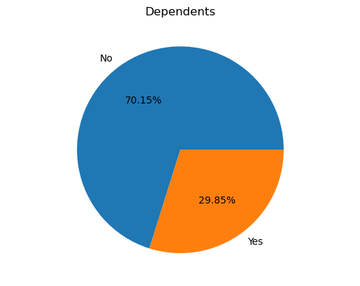

```
____________________________________________________________________________________________________
```

[figure not shown]

```
____________________________________________________________________________________________________
```

[figure not shown]

```
____________________________________________________________________________________________________
```

[figure not shown]

```
____________________________________________________________________________________________________
```

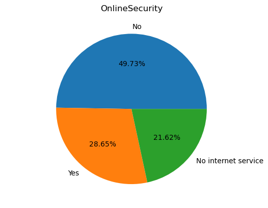

```
____________________________________________________________________________________________________
```

[figure not shown]

```
____________________________________________________________________________________________________
```

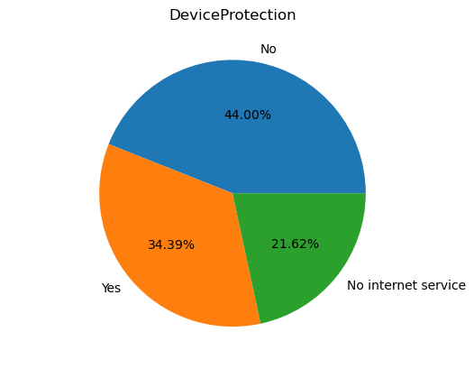

```
____________________________________________________________________________________________________
```

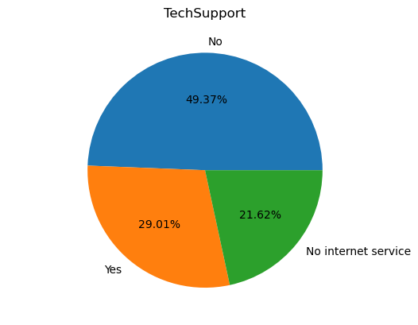

```
____________________________________________________________________________________________________
```

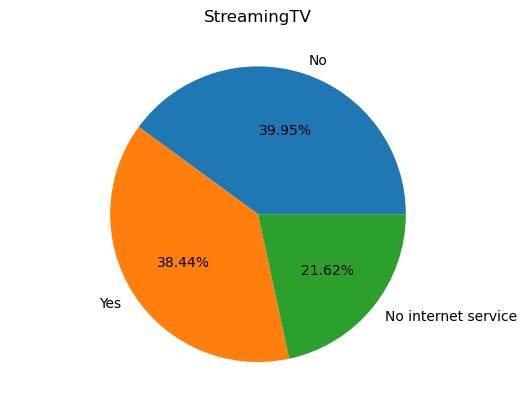

```
____________________________________________________________________________________________________
```

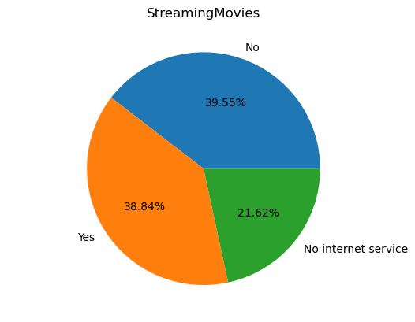

```
____________________________________________________________________________________________________
```

[4 more figures not shown]

```
____________________________________________________________________________________________________
```

```python
# Create a function that will accept a DataFrame as input and return pie-charts for all the appropriate Categorical features.
# Clearly show percentage distribution in the pie-chart.

# Libraries to handle data visualization
import matplotlib.pyplot as plt
import seaborn as sns
%matplotlib inline

# library for confusion_matrix
from sklearn.metrics import confusion_matrix

# lets convert all the object datatype to categorical varisble
for col in churn_data.columns:
    if churn_data[col].dtype == 'object':
        churn_data[col] = pd.Categorical(churn_data[col])

# all the string datatype features converted to categorical
# now lets define the function for pie chart
def makePieChart(df):
    for feature in df.columns:
        if df[feature].dtype.name == 'category':
            feature_values = list(df[feature].value_counts())
            feature_keys = list(df[feature].unique())
            plt.title(feature)
            plt.axis('equal')
            plt.pie(feature_values, labels=feature_keys, autopct='%0.2f%%')
            plt.show();
            print("_"*100)
            print("\n")

makePieChart(churn_data)
```

### Question 2.D:

```python
# Share insights for Q2.c.
```

### Question 2.E:

```python
# Encode all the appropriate Categorical features with the best suitable approach.

replaceData = {
    "Partner": { "No": 1, "Yes": 2 },
    "Dependents": { "No": 1, "Yes": 2 },
    "PhoneService": { "No": 1, "Yes": 2 },
    "PaperlessBilling": { "No": 1, "Yes": 2 },
    # "Contract": { "Month-to-month", 1, "One year": 2, "Two year": 3 },
    "Churn": {"No": 0, "Yes": 1 }
}
encodeOneHot = [ "gender", "MultipleLines", "InternetService", "OnlineSecurity", "OnlineBackup", "DeviceProtection", "TechSupport", "StreamingTV", "StreamingMovies", "Contract", "PaymentMethod" ]

churn_data=churn_data.replace(replaceData)
churn_data=pd.get_dummies(churn_data, columns=encodeOneHot)
churn_data.head()
```

|  | SeniorCitizen | Partner | Dependents | tenure | PhoneService | PaperlessBilling | MonthlyCharges | TotalCharges | Churn | gender_Female | ... | StreamingMovies_No | StreamingMovies_No internet service | StreamingMovies_Yes | Contract_Month-to-month | Contract_One year | Contract_Two year | PaymentMethod_Bank transfer (automatic) | PaymentMethod_Credit card (automatic) | PaymentMethod_Electronic check | PaymentMethod_Mailed check |
| --- | --- | --- | --- | --- | --- | --- | --- | --- | --- | --- | --- | --- | --- | --- | --- | --- | --- | --- | --- | --- | --- |
| 0 | 0 | 2 | 1 | 1 | 1 | 2 | 29.85 | 29.85 | 0 | 1 | ... | 1 | 0 | 0 | 1 | 0 | 0 | 0 | 0 | 1 | 0 |
| 1 | 0 | 1 | 1 | 34 | 2 | 1 | 56.95 | 1889.50 | 0 | 0 | ... | 1 | 0 | 0 | 0 | 1 | 0 | 0 | 0 | 0 | 1 |
| 2 | 0 | 1 | 1 | 2 | 2 | 2 | 53.85 | 108.15 | 1 | 0 | ... | 1 | 0 | 0 | 1 | 0 | 0 | 0 | 0 | 0 | 1 |
| 3 | 0 | 1 | 1 | 45 | 1 | 1 | 42.30 | 1840.75 | 0 | 0 | ... | 1 | 0 | 0 | 0 | 1 | 0 | 1 | 0 | 0 | 0 |
| 4 | 0 | 1 | 1 | 2 | 2 | 2 | 70.70 | 151.65 | 1 | 1 | ... | 1 | 0 | 0 | 1 | 0 | 0 | 0 | 0 | 1 | 0 |

5 rows × 42 columns

```python
churn_data.info()
```

```
<class 'pandas.core.frame.DataFrame'>
Int64Index: 7032 entries, 0 to 7042
Data columns (total 42 columns):
 #   Column                                   Non-Null Count  Dtype
---  ------                                   --------------  -----
 0   SeniorCitizen                            7032 non-null   int64
 1   Partner                                  7032 non-null   category
 2   Dependents                               7032 non-null   category
 3   tenure                                   7032 non-null   int64
 4   PhoneService                             7032 non-null   category
 5   PaperlessBilling                         7032 non-null   category
 6   MonthlyCharges                           7032 non-null   float64
 7   TotalCharges                             7032 non-null   float64
 8   Churn                                    7032 non-null   category
 9   gender_Female                            7032 non-null   uint8
```

[output cut: 34 more lines]

```python
# Still some columns are categorical type. lets change those to numetic
churn_data['Partner'] = pd.to_numeric(churn_data['Partner'])
churn_data['Dependents'] = pd.to_numeric(churn_data['Dependents'])
churn_data['PhoneService'] = pd.to_numeric(churn_data['PhoneService'])
churn_data['PaperlessBilling'] = pd.to_numeric(churn_data['PaperlessBilling'])
churn_data['Churn'] = pd.to_numeric(churn_data['Churn'])
```

```python
churn_data.info()
```

```
<class 'pandas.core.frame.DataFrame'>
Int64Index: 7032 entries, 0 to 7042
Data columns (total 42 columns):
 #   Column                                   Non-Null Count  Dtype
---  ------                                   --------------  -----
 0   SeniorCitizen                            7032 non-null   int64
 1   Partner                                  7032 non-null   int64
 2   Dependents                               7032 non-null   int64
 3   tenure                                   7032 non-null   int64
 4   PhoneService                             7032 non-null   int64
 5   PaperlessBilling                         7032 non-null   int64
 6   MonthlyCharges                           7032 non-null   float64
 7   TotalCharges                             7032 non-null   float64
 8   Churn                                    7032 non-null   int64
 9   gender_Female                            7032 non-null   uint8
```

[output cut: 34 more lines]

- Okay, now all the columns are nymeric only

### Question 2.F:

```python
# Split the data into 80% train and 20% test.

# import library to perform train test split
from sklearn.model_selection import train_test_split

churn_X = churn_data.drop("Churn", axis=1)
churn_y = churn_data["Churn"]
X_train, X_test, y_train, y_test = train_test_split(churn_X, churn_y, test_size = 0.20, random_state = 1)
churn_X.head()
```

|  | SeniorCitizen | Partner | Dependents | tenure | PhoneService | PaperlessBilling | MonthlyCharges | TotalCharges | gender_Female | gender_Male | ... | StreamingMovies_No | StreamingMovies_No internet service | StreamingMovies_Yes | Contract_Month-to-month | Contract_One year | Contract_Two year | PaymentMethod_Bank transfer (automatic) | PaymentMethod_Credit card (automatic) | PaymentMethod_Electronic check | PaymentMethod_Mailed check |
| --- | --- | --- | --- | --- | --- | --- | --- | --- | --- | --- | --- | --- | --- | --- | --- | --- | --- | --- | --- | --- | --- |
| 0 | 0 | 2 | 1 | 1 | 1 | 2 | 29.85 | 29.85 | 1 | 0 | ... | 1 | 0 | 0 | 1 | 0 | 0 | 0 | 0 | 1 | 0 |
| 1 | 0 | 1 | 1 | 34 | 2 | 1 | 56.95 | 1889.50 | 0 | 1 | ... | 1 | 0 | 0 | 0 | 1 | 0 | 0 | 0 | 0 | 1 |
| 2 | 0 | 1 | 1 | 2 | 2 | 2 | 53.85 | 108.15 | 0 | 1 | ... | 1 | 0 | 0 | 1 | 0 | 0 | 0 | 0 | 0 | 1 |
| 3 | 0 | 1 | 1 | 45 | 1 | 1 | 42.30 | 1840.75 | 0 | 1 | ... | 1 | 0 | 0 | 0 | 1 | 0 | 1 | 0 | 0 | 0 |
| 4 | 0 | 1 | 1 | 2 | 2 | 2 | 70.70 | 151.65 | 1 | 0 | ... | 1 | 0 | 0 | 1 | 0 | 0 | 0 | 0 | 1 | 0 |

5 rows × 41 columns

### Question 2.G:

```python
# Normalize/Standardize the data with the best suitable approach.

# import Standardization library
from sklearn.preprocessing import StandardScaler
scaler = StandardScaler()
churn_scaled_X = pd.DataFrame(scaler.fit_transform(churn_X))
churn_scaled_X.columns = churn_X.columns

# lets split the scaled data again
X_scaled_train, X_scaled_test, y_train, y_test = train_test_split(churn_scaled_X, churn_y, test_size = 0.20, random_state = 1, stratify=churn_y)
churn_scaled_X.head()
```

|  | SeniorCitizen | Partner | Dependents | tenure | PhoneService | PaperlessBilling | MonthlyCharges | TotalCharges | gender_Female | gender_Male | ... | StreamingMovies_No | StreamingMovies_No internet service | StreamingMovies_Yes | Contract_Month-to-month | Contract_One year | Contract_Two year | PaymentMethod_Bank transfer (automatic) | PaymentMethod_Credit card (automatic) | PaymentMethod_Electronic check | PaymentMethod_Mailed check |
| --- | --- | --- | --- | --- | --- | --- | --- | --- | --- | --- | --- | --- | --- | --- | --- | --- | --- | --- | --- | --- | --- |
| 0 | -0.440327 | 1.035617 | -0.652305 | -1.280248 | -3.056334 | 0.828939 | -1.161694 | -0.994194 | 1.009430 | -1.009430 | ... | 1.23636 | -0.52513 | -0.796849 | 0.902613 | -0.514537 | -0.561364 | -0.529976 | -0.525351 | 1.404764 | -0.543604 |
| 1 | -0.440327 | -0.965608 | -0.652305 | 0.064303 | 0.327189 | -1.206361 | -0.260878 | -0.173740 | -0.990658 | 0.990658 | ... | 1.23636 | -0.52513 | -0.796849 | -1.107895 | 1.943495 | -0.561364 | -0.529976 | -0.525351 | -0.711863 | 1.839576 |
| 2 | -0.440327 | -0.965608 | -0.652305 | -1.239504 | 0.327189 | 0.828939 | -0.363923 | -0.959649 | -0.990658 | 0.990658 | ... | 1.23636 | -0.52513 | -0.796849 | 0.902613 | -0.514537 | -0.561364 | -0.529976 | -0.525351 | -0.711863 | 1.839576 |
| 3 | -0.440327 | -0.965608 | -0.652305 | 0.512486 | -3.056334 | -1.206361 | -0.747850 | -0.195248 | -0.990658 | 0.990658 | ... | 1.23636 | -0.52513 | -0.796849 | -1.107895 | 1.943495 | -0.561364 | 1.886879 | -0.525351 | -0.711863 | -0.543604 |
| 4 | -0.440327 | -0.965608 | -0.652305 | -1.239504 | 0.327189 | 0.828939 | 0.196178 | -0.940457 | 1.009430 | -1.009430 | ... | 1.23636 | -0.52513 | -0.796849 | 0.902613 | -0.514537 | -0.561364 | -0.529976 | -0.525351 | 1.404764 | -0.543604 |

5 rows × 41 columns

### Question 3.A:

```python
# Train a model using Decision tree and check the performance of the model on train and test data

# import the library for DecisionTreeClassifier
from sklearn.tree import DecisionTreeClassifier

# lets try the DecisionTreeClassifier model using default 'gini' criteria to split
dTree = DecisionTreeClassifier(criterion = 'gini', random_state = 1)
dTree.fit(X_scaled_train, y_train)
```

```
DecisionTreeClassifier(random_state=1)
```

```python
# lets check the accuracy score of the model on train and test data
print("Performance on Training data =>", dTree.score(X_scaled_train, y_train))
print("Performance on Test data =>", dTree.score(X_scaled_test, y_test))
```

```
Performance on Training data => 0.9971555555555556
Performance on Test data => 0.7199715707178393
```

- We can clearly identify that the model is overfitting

```python
# lets check the max depth used by the model
dTree.tree_.max_depth
```

```
25
```

```python
# lets create another moder by reducing the overfinning
dTreeR = DecisionTreeClassifier(criterion = 'gini', max_depth = 3, random_state = 1)
dTreeR.fit(X_scaled_train, y_train)
```

```
DecisionTreeClassifier(max_depth=3, random_state=1)
```

```python
# Now lets see the performance, whether the overfitting is reduced or not
print("Performance on Training data =>", dTreeR.score(X_scaled_train, y_train))
print("Performance on Test data =>", dTreeR.score(X_scaled_test, y_test))
```

```
Performance on Training data => 0.7925333333333333
Performance on Test data => 0.7761194029850746
```

- Now we can see the overfitting is reduced

### Question 3.B:

```python
# Use grid search and improve the performance of the Decision tree model,

# Lets import the library for grid search
from sklearn.model_selection import GridSearchCV

# try some parameter for grid search
grid_param_DT = {
    'max_depth': range(1, 25),
    'criterion': [ 'gini', 'entropy' ]
}
grid_search = GridSearchCV(DecisionTreeClassifier(random_state = 1), grid_param_DT, cv = 5)
grid_search.fit(X_scaled_train, y_train)
```

```
GridSearchCV(cv=5, estimator=DecisionTreeClassifier(random_state=1),
             param_grid={'criterion': ['gini', 'entropy'],
                         'max_depth': range(1, 25)})
```

```python
# lets see the best score, best parameters
print(grid_search.best_score_)
print(grid_search.best_params_)
```

```
0.7964444444444444
{'criterion': 'entropy', 'max_depth': 5}
```

```python
# check the performance of the model on train and test data,
best_model_DT = grid_search.best_estimator_
best_model_DT.fit(X_scaled_train,y_train)
y_train_pred_DT = best_model_DT.predict(X_scaled_train)
y_test_pred_DT = best_model_DT.predict(X_scaled_test)
```

```
Performance on Training data => 0.8021333333333334
Performance on Test data => 0.7860696517412935
```

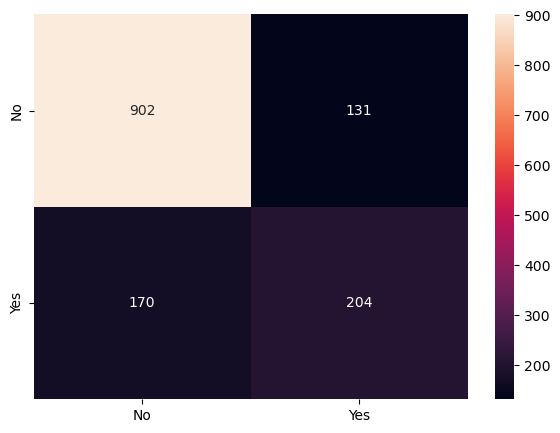

```python
print("Performance on Training data =>", best_model_DT.score(X_scaled_train, y_train))
print("Performance on Test data =>", best_model_DT.score(X_scaled_test, y_test))

# check the confusion_matrix
cm = confusion_matrix(y_test, y_test_pred_DT,labels=[0, 1])
df_cm = pd.DataFrame(cm, index = [i for i in ["No","Yes"]], columns = [i for i in ["No","Yes"]])
plt.figure(figsize = (7,5))
sns.heatmap(df_cm, annot = True, fmt = 'g');
```

```python
# provide the differences observed in performance in Q3.a and Q3.b
```

- we can see first the accuracy score was almost 100% on train and 72% on test data
- later it was improved to 79% and 77.6% respectively
- now the performance quite improved to 80% on train and 78.6% on test data

### Question 3.C:

```python
# Train a model using Random forest and check the performance of the model on train and test data

# import the library for Random Forest
from sklearn.ensemble import RandomForestClassifier
rfcl = RandomForestClassifier(n_estimators = 50, random_state = 1)
rfcl = rfcl.fit(X_scaled_train, y_train)
```

```python
# lets check the performance of the model on train and test data
print("Performance on Training data =>", rfcl.score(X_scaled_train, y_train))
print("Performance on Test data =>", rfcl.score(X_scaled_test, y_test))
```

```
Performance on Training data => 0.9968
Performance on Test data => 0.783226723525231
```

- Here also we can see the model in overfitting on test data

### Question 3.D:

```python
# Use grid search and improve the performance of the Random tree model,

# library for grid search already imported earlier on for the Decission Tree
# from sklearn.model_selection import GridSearchCV

# try some parameter for grid search
grid_param_RFC = {
    'class_weight': [{ 0: 0.25, 1: 0.75 }],
    'n_estimators': [ 50, 100, 200 ],
    'min_samples_leaf': np.arange(5, 10),
    'max_features': np.arange(0.3, 0.6, 0.1),
    'max_samples': np.arange(0.3, 0.6, 0.1)
}
grid_search_RFC = GridSearchCV(RandomForestClassifier(random_state = 1), grid_param_RFC, cv = 5)
grid_search_RFC.fit(X_scaled_train, y_train)
```

[output not shown]

[output cut: 244 more lines]

[output not shown]

```python
# lets see the best score, best parameters
print(grid_search_RFC.best_score_)
print(grid_search_RFC.best_params_)
```

[output not shown]

```python
# check the performance of the model on train and test data,
best_model_RFC = grid_search.best_estimator_
best_model_RFC.fit(X_scaled_train,y_train)
y_train_pred_RFC = best_model_RFC.predict(X_scaled_train)
y_test_pred_RFC = best_model_RFC.predict(X_scaled_test)
```

```python
print("Performance on Training data =>", best_model_RFC.score(X_scaled_train, y_train))
print("Performance on Test data =>", best_model_RFC.score(X_scaled_test, y_test))
```

[output not shown]

```python
# provide the differences observed in performance in Q3.c and Q3.d
```

### Question 3.E:

```python
# Train a model using Adaboost and check the performance of the model on train and test data
# import library for Adaboost
from sklearn.ensemble import AdaBoostClassifier
abcl = AdaBoostClassifier(random_state = 1)
abcl = abcl.fit(X_scaled_train, y_train)
```

```python
y_train_pred_AB = abcl.predict(X_scaled_train)
y_test_pred_AB = abcl.predict(X_scaled_test)
```

```
Performance on Training data => 0.808
Performance on Test data => 0.7938877043354655
```

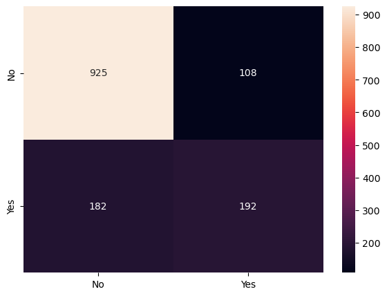

```python
print("Performance on Training data =>", abcl.score(X_scaled_train, y_train))
print("Performance on Test data =>", abcl.score(X_scaled_test, y_test))

# check the confusion_matrix
cm = confusion_matrix(y_test, y_test_pred_AB,labels=[0, 1])
df_cm = pd.DataFrame(cm, index = [i for i in ["No","Yes"]], columns = [i for i in ["No","Yes"]])
plt.figure(figsize = (7,5))
sns.heatmap(df_cm, annot = True, fmt = 'g');
```

### Question 3.F:

```python
# Use grid search and improve the performance of the Adaboost model,

# check the performance of the model on train and test data,
# provide the differences observed in performance in Q3.e and Q3.f
```

[output not shown]

### Question 3.G:

```python
# Train a model using GradientBoost and check the performance of the model on train and test data
# import library for GradientBoost
from sklearn.ensemble import GradientBoostingClassifier
gbcl = GradientBoostingClassifier(random_state = 1)
gbcl = gbcl.fit(X_scaled_train, y_train)
```

```python
# Now lets see the performance
print("Performance on Training data =>", gbcl.score(X_scaled_train, y_train))
print("Performance on Test data =>", gbcl.score(X_scaled_test, y_test))
```

```
Performance on Training data => 0.8314666666666667
Performance on Test data => 0.7967306325515281
```

```python
y_train_pred_GB = abcl.predict(X_scaled_train)
y_test_pred_GB = abcl.predict(X_scaled_test)
```

[figure not shown]

```python
# check the confusion_matrix
cm = confusion_matrix(y_test, y_test_pred_GB,labels=[0, 1])
df_cm = pd.DataFrame(cm, index = [i for i in ["No","Yes"]], columns = [i for i in ["No","Yes"]])
plt.figure(figsize = (7,5))
sns.heatmap(df_cm, annot = True, fmt = 'g');
```

### Question 3.H:

```python
# Use grid search and improve the performance of the GradientBoost model,
# check the performance of the model on train and test data,
# provide the differences observed in performance in Q3.g and Q3.h
```

[output not shown]

### Question 3.I.1:

```python
# Compare the performance of each model in train stage and test stage
```

### Question 3.I.2:

```python
# Provide your observation on which model performed the best
```

### Question 3.I.3:

```python
# Provide your reasoning on why the model performed best
```

### Question 3.I.4:

```python
# Provide your final conclusion on your observation
```